# Autoinformation (AIF) / Partial Autoinformation (PAIF)

This notebook contains the code and data examples as used in the article:  
F. von Wegner, Partial Autoinformation to Characterize Symbolic Sequences Front Physiol (2018) https://doi.org/10.3389/fphys.2018.01382

Feel free to use, improve, modify and distribute the code as you like. If your modified version still shows resemblance with my original code, please cite the article above.

```python
from aif_paif import *
```

## Examples

### [1] Markov chain of order 3

In this example, $X_{n+1}$ depends on $X_{n}, X_{n-1}, X_{n-2}$.

```
((100000,), dtype('int64'), set([0, 1]))
[+] Symbolic time series ns = 2
[+] AIF:
	AIF(k=0)
[+] PAIF:
	AIF(k=0)
	PAIF(k=5)
```

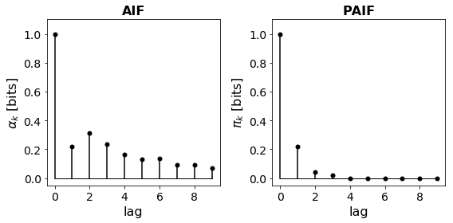

```python
x = np.load("mc_1_3.npy").astype('int')
print(x.shape, x.dtype, set(x))
ns = len(set(x))
print("[+] Symbolic time series ns = {:d}".format(ns))
plot_aif_paif(x, ns, kmax=10)
```

### [2] Another Markov chain or order 3

In this example, $X_{n+1}$ depends on $X_{n-2}$ only.

```
((100000,), dtype('int64'), set([0, 1]))
[+] Symbolic time series ns = 2
[+] AIF:
	AIF(k=0)
[+] PAIF:
	AIF(k=0)
	PAIF(k=5)
```

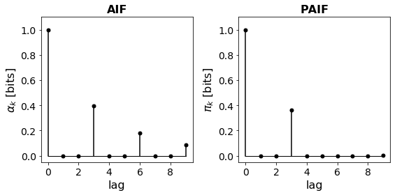

```python
x = np.load("mc_3.npy").astype('int')
print(x.shape, x.dtype, set(x))
ns = len(set(x))
print("[+] Symbolic time series ns = {:d}".format(ns))
plot_aif_paif(x, ns, kmax=10)
```

### [3] The non-Markovian even process

The even process is non-Markovian and in theory, has infinite memory.

```
((100000,), dtype('int64'), set([0, 1]))
[+] Symbolic time series ns = 2
[+] AIF:
	AIF(k=0)
[+] PAIF:
	AIF(k=0)
	PAIF(k=5)
```

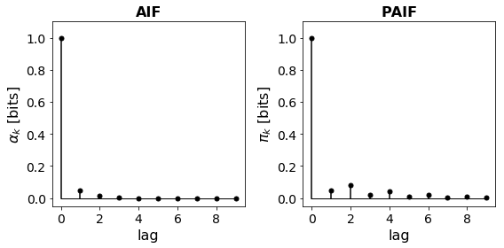

```python
x = np.load("even.npy").astype('int')
print(x.shape, x.dtype, set(x))
ns = len(set(x))
print("[+] Symbolic time series ns = {:d}".format(ns))
plot_aif_paif(x, ns, kmax=10)
```

### [4] The 2-state golden-mean process

This Hidden Markov Model (HMM) representation of the golden mean process uses two hidden and two observable states. The Markov order is 1.

```
((100000,), dtype('int64'), set([0, 1]))
[+] Symbolic time series ns = 2
[+] AIF:
	AIF(k=0)
[+] PAIF:
	AIF(k=0)
	PAIF(k=5)
```

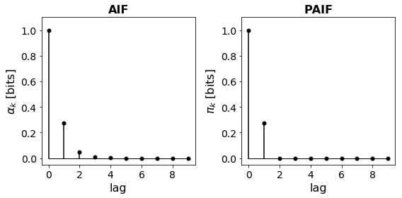

```python
x = np.load("gm2.npy").astype('int')
print(x.shape, x.dtype, set(x))
ns = len(set(x))
print("[+] Symbolic time series ns = {:d}".format(ns))
plot_aif_paif(x, ns, kmax=10)
```

### [5] The 7-state golden mean process

This alternative Hidden Markov Model implementation of the golden-mean process uses a Markov order of 4 and so-called cryptic order 3.

```
((100000,), dtype('int64'), set([0, 1]))
[+] Symbolic time series ns = 2
[+] AIF:
	AIF(k=0)
[+] PAIF:
	AIF(k=0)
	PAIF(k=5)
```

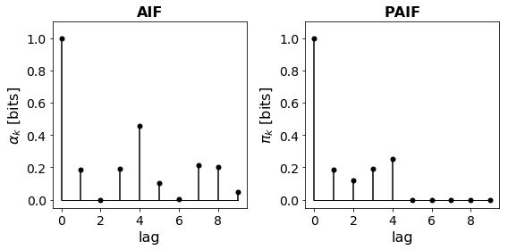

```python
x = np.load("gm7.npy").astype('int')
print(x.shape, x.dtype, set(x))
ns = len(set(x))
print("[+] Symbolic time series ns = {:d}".format(ns))
plot_aif_paif(x, ns, kmax=10)
```

### [6] The Ising model

The Ising model on a square finite lattice with periodic BC is run close to the critical point.

```
((1000000,), dtype('int64'), set([0, 1]))
[+] Symbolic time series ns = 2
[+] AIF:
	AIF(k=0)
[+] PAIF:
	AIF(k=0)
	PAIF(k=5)
```

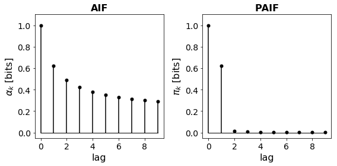

```python
x = np.load("Ising2D_L50_N1000000_Temp2.27.npy").astype('int')
print(x.shape, x.dtype, set(x))
ns = len(set(x))
print("[+] Symbolic time series ns = {:d}".format(ns))
plot_aif_paif(x, ns, kmax=10)
```

This sample contains data from the Ising model at a *hot* temperature.

```
((1000000,), dtype('int64'), set([0, 1]))
[+] Symbolic time series ns = 2
[+] AIF:
	AIF(k=0)
[+] PAIF:
	AIF(k=0)
	PAIF(k=5)
```

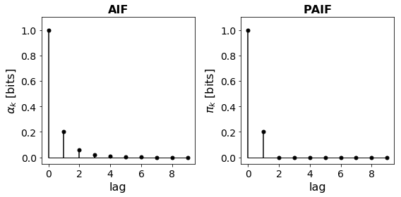

```python
x = np.load("Ising2D_L50_N1000000_Temp5.00.npy").astype('int')
print(x.shape, x.dtype, set(x))
ns = len(set(x))
print("[+] Symbolic time series ns = {:d}".format(ns))
plot_aif_paif(x, ns, kmax=10)
```

### [7] Simulated ion channel data

An abstract ion channel is modelled using a particle moving in a quartic potential.

```
((1000000,), dtype('int64'), set([0, 1]))
[+] Symbolic time series ns = 2
[+] AIF:
	AIF(k=0)
[+] PAIF:
	AIF(k=0)
	PAIF(k=5)
```

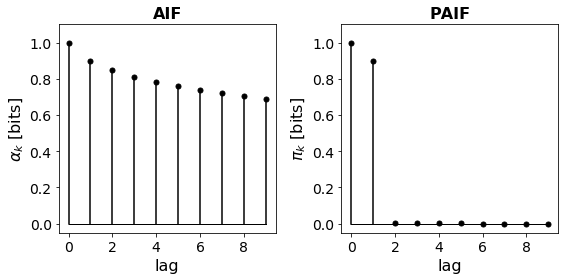

```python
x = np.load("ch.npy").astype('int')
print(x.shape, x.dtype, set(x))
ns = len(set(x))
print("[+] Symbolic time series ns = {:d}".format(ns))
plot_aif_paif(x, ns, kmax=10)
```

### [8] EEG microstate sequence

This example contains a 4-state symbolic sequence representing the sequence of spatial patterns measured by surface electroencephalography (EEG) from a healthy subject in a task-free (resting state) condition.

```
((153225,), dtype('int64'), set([0, 1, 2, 3]))
[+] Symbolic time series ns = 4
[+] AIF:
	AIF(k=0)
[+] PAIF:
	AIF(k=0)
	PAIF(k=5)
```

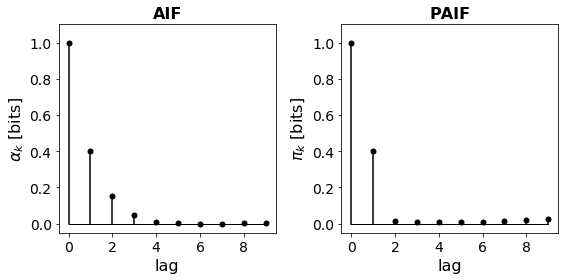

```python
x = np.load("eeg_ms.npy").astype('int')
print(x.shape, x.dtype, set(x))
ns = len(set(x))
print("[+] Symbolic time series ns = {:d}".format(ns))
plot_aif_paif(x, ns, kmax=10)
```

```
[+] Markov surrogates, order M = 1
[+] AIF:
	AIF(k=0)
[+] PAIF:
	AIF(k=0)
	PAIF(k=5)
```

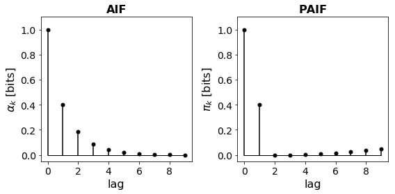

```
[+] Markov surrogates, order M = 2
[+] AIF:
	AIF(k=0)
[+] PAIF:
	AIF(k=0)
	PAIF(k=5)
```

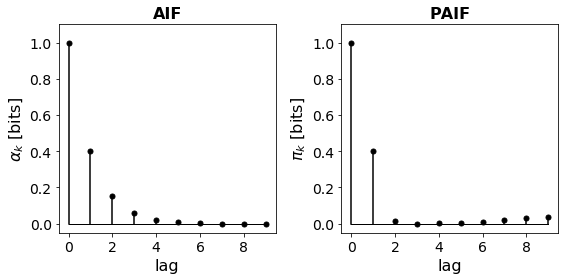

```
[+] Markov surrogates, order M = 3
[+] AIF:
	AIF(k=0)
[+] PAIF:
	AIF(k=0)
	PAIF(k=5)
```

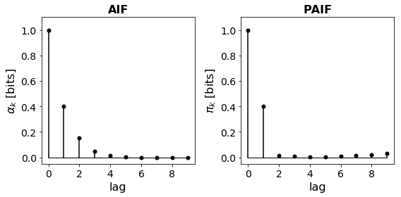

```
[+] Markov surrogates, order M = 4
[+] AIF:
	AIF(k=0)
[+] PAIF:
	AIF(k=0)
	PAIF(k=5)
```

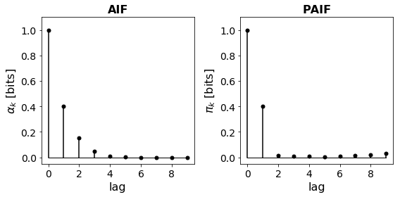

```python
#''' Markov surrogates
for M in range(1,5):
    print("\n[+] Markov surrogates, order M = {:d}".format(M))
    pk, Tk = Tk_hat(x, ns, M)
    y = mc_k(pk, Tk, M, ns, len(x))
    plot_aif_paif(y, ns, kmax=10)
#'''
```